# MCMC "Intelligence"

The gist of the idea is that we need to flip the way we are looking at the problem. What we did was define a measure (intelligence) and then sought an algorithm that could sample efficiently from intelligences. Unfortunately, this was difficult because algorithms like MCMC need to satisfy detail balance (and some other properties). So, we were stuck looking for a smart way to sample and maybe "skip over" some of the inner loop.

Here, I take the opposite approach. Instead of deriving a quantity in which to base the probabilities, I first defined an algorithm that captures the idea of intelligence that is easier to sample from. (namely MCMC) and then defined an accept/reject criteria (ratio of probabilities) that fit in the algorithm and also "made sense" in the game theoretic way (i.e. it is close to intelligence). Let's take a look...

Here I only present the procedure/idea/ for games of perfect information

*The trick : Instead of defining probabilities of the PGT posterior, we define odds.*

We still want to capture some of the essence of intelligence so I chose to define odds as follows:

In a two player game, if $s_1$ and $s_2$ are strategy profiles for player 1 and player 2. Then the PGT posterior odds of the profile $(s_1, s_2)$ to some alternative strategy profile $(s_1', s_2')$ is given by:

\begin{align} \frac{P(s_1, s_2)}{P(s_1', s_2')} \propto \frac{exp(\alpha EU_1(s_1, s_2))}{exp(\alpha EU_1(s_1', s_2))} \times \frac{ exp(\alpha EU_2(s_1, s_2))}{exp(\alpha EU_2(s_1, s_2'))}\times\frac{exp(\alpha EU_1(s_1, s_2'))}{exp(\alpha EU_1(s_1', s_2'))} \times \frac{exp(\alpha EU_2(s_1', s_2))}{exp(\alpha EU_2(s_1', s_2'))} \\ %&\propto \frac{exp\bigg(\alpha\big(EU_1(s_1, s_2) + EU_2(s_1, s_2) +EU_1(s_1, s_2') + EU_2(s_1', s_2)\big)\bigg)}%%{exp\bigg[\alpha\bigg(EU_1(s_1', s_2) + EU_2(s_1, s_2') + EU_1(s_1', s_2')+EU_2(s_1', s_2')\big)\bigg) } \propto exp\bigg(\alpha\big(EU_1(s_1, s_2) + EU_2(s_1, s_2) +EU_1(s_1, s_2') + EU_2(s_1', s_2) - EU_1(s_1', s_2) - EU_2(s_1, s_2') - EU_1(s_1', s_2')-EU_2(s_1', s_2')\big)\bigg) \end{align}

where $EU_i$, $i=1,2$ is the expected utility of player $i$ under the profiles in the argument of the function.

The tie this into the idea of intelligence, consider the first two terms. These capture the "intelligence" of the profile $(s_1, s_2)$. We only sample one other profile (namely $(s_1', s_2')$) which might seem insufficient. However, we are not concerned about capturing the intelligence of $(s_1, s_2)$ over all strategy profiles. Instead, we are just trying to capture the intelligence of $(s_1, s_2)$ when the alternative for the players are $(s_1', s_2')$. I like to call this "pairwise intelligence" The third and fourth term can be considered the multiplicative inverse of the "pairwise intelligence" of $(s_1', s_2')$. The prodct of the exponential of all four terms is a measure that attempts to capture the difference in "pairwise intelligence." As the pairwise intelligence of $(s_1, s_2)$ increases, the odds ratio as defined above increases. Of course, as the pairwise intelligence of $(s_1', s_2')$ increases the odds rate above decreases.

Another way to think about it is that the first term captures the idea of intelligence while the second term captures the idea of dominance. In other words, higher odds are assigned to profiles where the strategies do well against each other but also do well against some of the opponents other strategies.

The $\alpha$ parameter controls the responsiveness of the probability to differences in intelligences. Also the need for exponentiating is give a monotone mapping of expected utilities onto $\mathbf{R}^+$ while also preserving 1) below.

The following properties hold :

1. \begin{equation} \frac{P(s_1, s_2)}{P(s_1', s_2')} = \frac{1}{\frac{P(s_1', s_2')}{P(s_1, s_2)}} \end{equation}
2. Any strategy profile where players are both playing dominant strategies receives the highest probability.
3. All Nash equilibrium profiles do *not* receive the same weight. Instead, the weight they are assigned depends on how they perform against non-equilibrium strategies.

So why did I do this? If it isn't already clear, if we define the PGT distribution in terms of odds instead of probabilities, we can do MCMC by sampling strategy profiles uniformly and then accepting/rejecting based on the odds ratio. Note that getting a sample of the PGT distribution only requires evaluating the expected utility of 4 strategy profiles. Also note that the only way this grows is with the number of players.

### The algorithm

- Start at an initial profile
- Uniformly select another profile
- Accept/Reject the new profile based on the odds.
- After a burn in, we are sampling from the PGT distirbution

### The Code -Click "Toggle Input" to turn code off

```python
import itertools
from IPython.display import Image
import numpy as np
from matplotlib import pyplot as plt
%matplotlib inline
from adsy.display import extended_styles
from collections import defaultdict
from adsy.display import extended_styles
extended_styles()
```

Toggle Input

```python
perfect_strat_1 = list(itertools.product(["A", "B", "C"], ["A", "B", "C"]))
perfect_strat_2 = list(itertools.product(["X", "Y", "Z"], ["X", "Y", "Z"], ["X", "Y", "Z"],
                                         ["X", "Y", "Z"], ["X", "Y", "Z"], ["X", "Y", "Z"]))
perfect_stratprofiles = list(itertools.product(perfect_strat_1, perfect_strat_2))
mapdict = {"A": 0, "B":1, "C":2}
utils = {"HAX": (625, 312),
         "HAY": (1000, 200),
         "HAZ": (900, 252),
         "HBX": (550, 687.5),
         "HBY": (300, 350),
         "HBZ": (660, 462),
         "HCX": (427, 762),
         "HCY": (532, 380),
         "HCZ": (504, 504),
         "LAX": (-2000, -1000),
         "LAY": (-1200, -250),
         "LAZ": (-1500, -420),
         "LBX": (-125, -156),
         "LBY": (250, 125),
         "LBZ": (150, 105),
         "LCX": (17, 31),
         "LCY": (280, 200),
         "LCZ": (210, 210)
}
def EU_perfect_info(p1strat, p2strat, utils=utils, p1top2map=mapdict):
    """
    Computes the expected utility of player 1 and player 2.

    Nature node is hard coded to p=.5 for both outcomes.

    Setting trembleprobs to 0 gives standard intelligence
    """
    highukey = "H"+p1strat[0]+p2strat[mapdict[p1strat[0]]]
    lowukey =  "L"+p1strat[1]+p2strat[3 + mapdict[p1strat[1]]]
    p1eunotremb = .5 * utils[highukey][0] + .5 * utils[lowukey][0]
    p2eunotremb = .5 * utils[highukey][1] + .5 * utils[lowukey][1]
    return p1eunotremb, p2eunotremb
```

```python
# Here we do the MCMC
numiters = 1000
exparam = .0025
mcmcres = []
mcmcutils =[]
ixlist = np.arange(0, len(perfect_stratprofiles))
s0 = perfect_stratprofiles[np.random.choice(ixlist)]
for prop in xrange(numiters):
    s1 = perfect_stratprofiles[np.random.choice(ixlist)]
    arcriteria = np.exp(exparam * (sum(EU_perfect_info(s1[0], s1[1])) - sum(EU_perfect_info(s0[0], s0[1]))
                                   + EU_perfect_info(s1[0], s0[1])[0] + EU_perfect_info(s0[0], s1[1])[1]
                                   - EU_perfect_info(s0[0], s1[1])[0] - EU_perfect_info(s1[0], s0[1])[1]))

    #num =  np.exp(exparam * EU_perfect_info(s1[0], sc[1])[0]) * np.exp(exparam*EU_perfect_info(sc[0], s1[1])[1])
    #denom =  np.exp(exparam*EU_perfect_info(s0[0], sc[1])[0]) * np.exp(exparam*EU_perfect_info(sc[0], s0[1])[1])
    unew = EU_perfect_info(s1[0], s1[1])
    #num  = np.prod(unew)
    uold = EU_perfect_info(s0[0], s0[1])
    #denom = np.prod(uold)
    #num*= np.exp(exparam * EU_perfect_info(s1[0],s0[1])[0]) * np.exp(exparam*EU_perfect_info(s0[0], s1[1])[1])
    #denom*= np.exp(exparam * EU_perfect_info(s0[0], s1[1])[0]) *  np.exp(exparam * EU_perfect_info(s1[0],s0[1])[1])
    #arcriteria = (num/denom)
    #arcriteria = 1
    if np.random.random() < arcriteria:
        mcmcres.append(s1)
        s0 = s1
        mcmcutils.append(unew)
    else:
        mcmcres.append(s0)
        mcmcutils.append(uold)
```

### Let's look at the histogram of expected utilities - 1000 profiles sampled

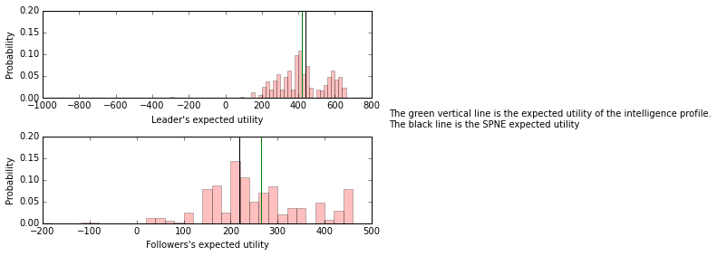

```python
mcmcutils = np.asarray(mcmcutils)
eu_subgame_perfect = [(625+250)/2. , (312. + 125.)/2.]
fig, (ax1, ax2) = plt.subplots(2)
weights1 = np.ones_like(mcmcutils[200:, 0])/len(mcmcutils[200:, 0])
ax1.hist(mcmcutils[200:, 0], weights=weights1, bins=np.arange(-900,800,20), color='r', alpha=.25)
ax1.set_xlabel("Leader\'s expected utility")
ax1.set_ylabel("Probability")
ax1.vlines(eu_subgame_perfect[0], 0, .2)
ax1.vlines(np.mean(mcmcutils[200:,0]), 0, .2, color='green')
weights2 = np.ones_like(mcmcutils[200:, 1])/len(mcmcutils[200:, 1])
ax2.hist(mcmcutils[200:, 1], weights=weights2, bins=np.arange(-200,500,20), color='r', alpha=.25)
ax2.set_xlabel("Followers\'s expected utility")
ax2.set_ylabel("Probability")
ax2.vlines(eu_subgame_perfect[1], 0, .2)
ax2.vlines(np.mean(mcmcutils[200:,1]), 0, .2, color='green')
plt.tight_layout()
fig.text(1, .5, 'The green vertical line is the expected utility of the intelligence profile. \n' + \
                        'The black line is the SPNE expected utility')
```

### Let's compare it to the trembling hand and the information-set versions ...

```python
def EU_with_trembles_perfect_info(p1strat, p2strat, utils=utils, p1top2map=mapdict, p1trembleprob=.2,
                     p2trembleprob=.2, p1tremblestrats=perfect_strat_1, p2tremblestrats=perfect_strat_2):
    """
    Computes the expected utility of player 1 and player 2.

    Nature node is hard coded to p=.5 for both outcomes.

    Setting trembleprobs to 0 gives standard intelligence
    """
    highukey = "H"+p1strat[0]+p2strat[mapdict[p1strat[0]]]
    lowukey =  "L"+p1strat[1]+p2strat[3 + mapdict[p1strat[1]]]
    p1eunotremb = (1-p2trembleprob) * (.5 * utils[highukey][0] + .5 * utils[lowukey][0])
    p2eunotremb = (1-p1trembleprob) * (.5 * utils[highukey][1] + .5 * utils[lowukey][1])
    if p1trembleprob + p2trembleprob ==0:
        return p1eunotremb, p2eunotremb
    ### Get the utility that is associated with p2 trembling
    p1epovern = p1trembleprob/float(len(p1tremblestrats) - 1)
    p2epovern = p2trembleprob/float(len(p2tremblestrats) - 1)
    p1tremblingeu = 0 # Utility of p1 when p2 trembles
    p2tremblingeu = 0 # Utility of p2 when p1 trembles
    for s in p2tremblestrats:
        if s != p2strat:
            highukey = "H"+p1strat[0]+s[mapdict[p1strat[0]]]
            lowukey =  "L"+p1strat[1]+s[3 + mapdict[p1strat[1]]]
            p1tremblingeu += p2epovern * (.5 * utils[highukey][0] + .5 * utils[lowukey][0])
    for s in p1tremblestrats:
        if s != p1strat:
            highukey = "H"+s[0]+p2strat[mapdict[s[0]]]
            lowukey =  "L"+s[1]+p2strat[3 + mapdict[s[1]]]
            p2tremblingeu += p1epovern * (.5 * utils[highukey][1] + .5 * utils[lowukey][1])
    return p1eunotremb + p1tremblingeu, p2eunotremb + p2tremblingeu

def get_trembling_intelligence_perfect_info(profile, p1trembleprob=.2, p2trembleprob=.2):
    """
    Get's the trembling intelligence of a profile under trembling
    """
    p1strat = profile[0]
    p2strat = profile[1]
    util = EU_with_trembles_perfect_info(p1strat, p2strat, p1trembleprob=p1trembleprob, p2trembleprob=p2trembleprob)
    #print util
    p1_numalt = float(len(perfect_strat_1))
    p2_numalt = float(len(perfect_strat_2))
    num_no_betterp1 = 0
    num_no_betterp2 = 0
    for s in perfect_strat_1:
        if EU_with_trembles_perfect_info(s, p2strat, p1trembleprob=p1trembleprob, p2trembleprob=p2trembleprob)[0] <= util[0]:
            num_no_betterp1 +=1
    for s in perfect_strat_2:
        if EU_with_trembles_perfect_info(p1strat, s, p1trembleprob=p1trembleprob, p2trembleprob=p2trembleprob)[1] <= util[1]:
            num_no_betterp2 +=1
    return (num_no_betterp1-1)/(p1_numalt - 1) * (num_no_betterp2 - 1)/(p2_numalt -1)

class TremblingIntelResults(object):
    def __init__(self, res, stratprofiles = perfect_stratprofiles, perfect_strat_1=perfect_strat_1,
                 perfect_strat_2=perfect_strat_2):
        self.res = np.asarray(res)
        self.stratprofiles = stratprofiles
        self.sorted_ix = np.argsort(self.res)[::-1]
        self.perfect_strat_1 = perfect_strat_1
        self.perfect_strat_2 = perfect_strat_2

    def make_hist(self):
        plt.hist(self.res)

    def EU_perfect_info(self, p1strat, p2strat, utils=utils, p1top2map=mapdict):
        """
        No trembling EU.  USed to get Nash-eq
        """
        highukey = "H"+p1strat[0]+p2strat[mapdict[p1strat[0]]]
        lowukey =  "L"+p1strat[1]+p2strat[3 + mapdict[p1strat[1]]]
        p1eu = .5 * utils[highukey][0] + .5 * utils[lowukey][0]
        p2eu = .5 * utils[highukey][1] + .5 * utils[lowukey][1]
        return p1eu, p2eu

    def get_perfect_intelligence(profile):
        """
        Get's the non-trembling intelligences"""
        p1strat = profile[0]
        p2strat = profile[1]
        util = EU_perfect_info(p1strat, p2strat)
        #print util
        p1_numalt = float(len(self.perfect_strat_1))
        p2_numalt = float(len(self.perfect_strat_2))
        num_no_betterp1 = 0
        num_no_betterp2 = 0
        for s in self.perfect_strat_1:
            if EU_perfect_info(s, p2strat)[0] <= util[0]:
                num_no_betterp1 +=1
        for s in self.perfect_strat_2:
            if EU_perfect_info(p1strat, s)[1] <= util[1]:
                num_no_betterp2 +=1
        return (num_no_betterp1-1)/(p1_numalt - 1) * (num_no_betterp2 - 1)/(p2_numalt -1)

    def get_perfect_info_dist():
        intels_perfect = []
        for p in self.stratprofiles:
            intels_perfect.append(self.get_perfect_intelligence(p))
        return intels_perfect

    def eu_dist(self, power = 1, binwidth=10):
        total_prob = np.sum(self.res**power)
        probs = self.res**power/float(total_prob)
        eus = []
        for s in self.stratprofiles:
            eus.append(self.EU_perfect_info(s[0], s[1]))
        p1u = defaultdict(int)
        p2u = defaultdict(int)
        for ix, atom in enumerate(eus):
            p1u[int(atom[0]/binwidth) * binwidth ] += probs[ix]
            p2u[int(atom[1]/binwidth) * binwidth ] += probs[ix]
        return p1u, p2u

    def eu_hist(self, power=1, binwidth=10):
        eu_dicts = self.eu_dist(power=power, binwidth=binwidth)
        eu_subgame_perfect = [(625+250)/2. , (312. + 125.)/2.]
        eu_dicts_exact = self.eu_dist(power=power, binwidth=1)
        p1eeu = 0
        p2eeu = 0
        for k, v in eu_dicts_exact[0].iteritems():
            p1eeu += k * v
        for k, v in eu_dicts_exact[1].iteritems():
            p2eeu += k * v
        fig, [ax1, ax2] = plt.subplots(2)
        ax1.bar(eu_dicts[0].keys(), eu_dicts[0].values(), width=binwidth, color='r', alpha=.35)
        ax1.set_xlabel("Leader\'s expected utility")
        ax1.set_ylabel("Probability")
        ax1.vlines(eu_subgame_perfect[0], 0, .2)
        ax1.vlines(p1eeu, 0, .2, color='green')
        ax2.bar(eu_dicts[1].keys(), eu_dicts[1].values(), width=binwidth, color='r', alpha=.25)
        ax2.set_xlabel("Followers\'s expected utility")
        ax2.set_ylabel("Probability")
        ax2.vlines(eu_subgame_perfect[1], 0, .2)
        ax2.vlines(p2eeu, 0, .2, color='green')
        plt.tight_layout()
        fig.text(1, .5, 'The green vertical line is the expected utility of the intelligence profile. \n' + \
                        'The black line is the SPNE expected utility')
        return fig, ax1, ax2

    def eu_cdf(self, power=1):
        p1_dist, p2_dist = self.eu_dist( power = power)
        p1k = p1_dist.keys()
        p1v = p1_dist.values()
        p1_srtd = np.argsort(p1k)
        cumprob_p1 = np.cumsum(np.asarray(p1v)[p1_srtd])
        p2k = p2_dist.keys()
        p2v = p2_dist.values()
        p2_srtd = np.argsort(p2k)
        cumprob_p2 = np.cumsum(np.asarray(p2v)[p2_srtd])
        fig, [ax1, ax2] = plt.subplots(2)
        ax1.plot(np.asarray(p1k)[p1_srtd], cumprob_p1)
        ax1.set_xlabel("CDF of Leader\'s Utility")
        ax2.plot(np.asarray(p2k)[p2_srtd], cumprob_p2)
        ax2.set_xlabel("CDF of Followers\'s Utility")
        plt.tight_layout()
        return fig, ax1, ax2
```

#### First the trembling Hand

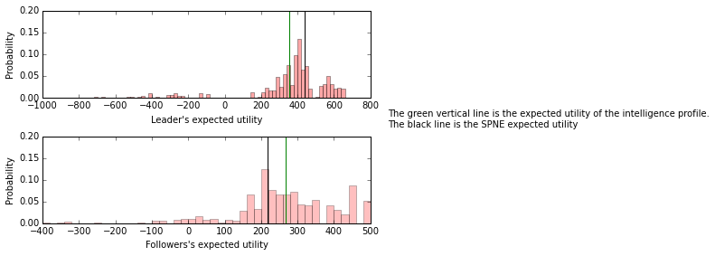

```python
#Uncomment to run simulation
#p1tremb=.1
#p2tremb=.1
#trembling_intels_perfect2 = []
#for p in perfect_stratprofiles:
#    trembling_intels_perfect2.append(get_trembling_intelligence_perfect_info(p, p1tremb,p2tremb))
res_tremble10 = TremblingIntelResults(trembling_intels_perfect2)
res_tremble10.eu_hist(binwidth=20, power=1);
```

Also a note on trembling hand. The subgame perfect equilibrium is not necessarily guaranteed to be the profile with the highest probability. The reason is that if the follwower trembles, the cost to the leader would be enough so that leader changes his strategy to avoid the costly tremble.

#### Now the off path intelligence

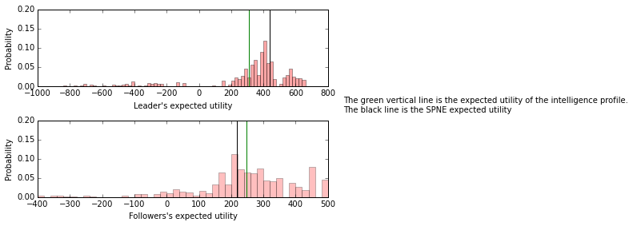

```python
p1tremb=0
p2tremb=0
no_trembling_intels = []
for p in perfect_stratprofiles:
    no_trembling_intels.append(get_trembling_intelligence_perfect_info(p, p1tremb, p2tremb))
on_path_intel = no_trembling_intels # Copied from above just for new varname.
p2_info_sets = ["HA", "HB", "HC", "LA", "LB", "LC"]
def get_off_path_info_sets(profile, p2_info_sets = p2_info_sets):
    unvisited = set(p2_info_sets) - set(["H" + profile[0][0]])
    unvisited = unvisited - set(["L" + profile[0][1]])
    return unvisited
def get_off_path_intel_perfect_info(profile, p=.5):
    unvisited = list(get_off_path_info_sets(profile))
    unvisited_intels = []
    for u in unvisited:
        num_no_better = 0.
        nature = u[0]
        p1act = u[1]
        p2s_action = profile[1][(3 * int(nature=="L")) +  mapdict[p1act]]
        utility = utils[nature + p1act + p2s_action][1]
        p2s_other_actions = list(set(["X", "Y", "Z"]) - set(p2s_action))
        for other in p2s_other_actions:
            utility_other = utils[u + other][1]
            if utility_other <= utility:
                num_no_better +=1
        unvisited_intels.append(num_no_better/2.)
    return sum(unvisited_intels)/float(len(unvisited_intels))

combined_intels1 = []
off_path_weight=.1
for ix, s in enumerate(perfect_stratprofiles):
      combined_intels1.append( (1 - off_path_weight) * on_path_intel[ix] + off_path_weight * get_off_path_intel_perfect_info(s))
off_path_res1 = TremblingIntelResults(combined_intels1) # Class name is a misnomer.  Can be used for any results class
off_path_res1.eu_hist(binwidth=20, power=1);
```

### And just for kicks...

We can vary the exponent parameter to get tighter distribution ...

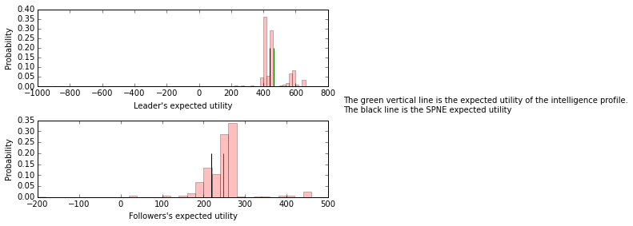

```python
numiters = 1000
exparam = .05
mcmcres = []
mcmcutils =[]
ixlist = np.arange(0, len(perfect_stratprofiles))
s0 = perfect_stratprofiles[np.random.choice(ixlist)]
for prop in xrange(numiters):
    s1 = perfect_stratprofiles[np.random.choice(ixlist)]
    arcriteria = np.exp(exparam * (sum(EU_perfect_info(s1[0], s1[1])) - sum(EU_perfect_info(s0[0], s0[1]))
                                   + EU_perfect_info(s1[0], s0[1])[0] + EU_perfect_info(s0[0], s1[1])[1]
                                   - EU_perfect_info(s0[0], s1[1])[0] - EU_perfect_info(s1[0], s0[1])[1]))

    #num =  np.exp(exparam * EU_perfect_info(s1[0], sc[1])[0]) * np.exp(exparam*EU_perfect_info(sc[0], s1[1])[1])
    #denom =  np.exp(exparam*EU_perfect_info(s0[0], sc[1])[0]) * np.exp(exparam*EU_perfect_info(sc[0], s0[1])[1])
    unew = EU_perfect_info(s1[0], s1[1])
    #num  = np.prod(unew)
    uold = EU_perfect_info(s0[0], s0[1])
    #denom = np.prod(uold)
    #num*= np.exp(exparam * EU_perfect_info(s1[0],s0[1])[0]) * np.exp(exparam*EU_perfect_info(s0[0], s1[1])[1])
    #denom*= np.exp(exparam * EU_perfect_info(s0[0], s1[1])[0]) *  np.exp(exparam * EU_perfect_info(s1[0],s0[1])[1])
    #arcriteria = (num/denom)
    #arcriteria = 1
    if np.random.random() < arcriteria:
        mcmcres.append(s1)
        s0 = s1
        mcmcutils.append(unew)
    else:
        mcmcres.append(s0)
        mcmcutils.append(uold)

mcmcutils = np.asarray(mcmcutils)
eu_subgame_perfect = [(625+250)/2. , (312. + 125.)/2.]
fig, (ax1, ax2) = plt.subplots(2)
weights1 = np.ones_like(mcmcutils[200:, 0])/len(mcmcutils[200:, 0])
ax1.hist(mcmcutils[200:, 0], weights=weights1, bins=np.arange(-900,800,20), color='r', alpha=.25)
ax1.set_xlabel("Leader\'s expected utility")
ax1.set_ylabel("Probability")
ax1.vlines(eu_subgame_perfect[0], 0, .2)
ax1.vlines(np.mean(mcmcutils[200:,0]), 0, .2, color='green')
weights2 = np.ones_like(mcmcutils[200:, 1])/len(mcmcutils[200:, 1])
ax2.hist(mcmcutils[200:, 1], weights=weights2, bins=np.arange(-200,500,20), color='r', alpha=.25)
ax2.set_xlabel("Followers\'s expected utility")
ax2.set_ylabel("Probability")
ax2.vlines(eu_subgame_perfect[1], 0, .2)
ax2.vlines(np.mean(mcmcutils[200:,1]), 0, .2, color='green')
plt.tight_layout()
fig.text(1, .5, 'The green vertical line is the expected utility of the intelligence profile. \n' + \
                        'The black line is the SPNE expected utility')
```

or a wider one

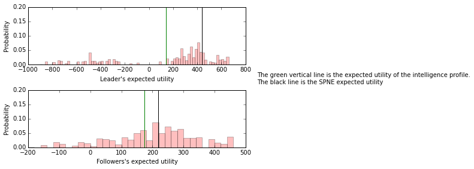

```python
numiters = 1000
exparam = .0001
mcmcres = []
mcmcutils =[]
ixlist = np.arange(0, len(perfect_stratprofiles))
s0 = perfect_stratprofiles[np.random.choice(ixlist)]
for prop in xrange(numiters):
    s1 = perfect_stratprofiles[np.random.choice(ixlist)]
    arcriteria = np.exp(exparam * (sum(EU_perfect_info(s1[0], s1[1])) - sum(EU_perfect_info(s0[0], s0[1]))
                                   + EU_perfect_info(s1[0], s0[1])[0] + EU_perfect_info(s0[0], s1[1])[1]
                                   - EU_perfect_info(s0[0], s1[1])[0] - EU_perfect_info(s1[0], s0[1])[1]))

    #num =  np.exp(exparam * EU_perfect_info(s1[0], sc[1])[0]) * np.exp(exparam*EU_perfect_info(sc[0], s1[1])[1])
    #denom =  np.exp(exparam*EU_perfect_info(s0[0], sc[1])[0]) * np.exp(exparam*EU_perfect_info(sc[0], s0[1])[1])
    unew = EU_perfect_info(s1[0], s1[1])
    #num  = np.prod(unew)
    uold = EU_perfect_info(s0[0], s0[1])
    #denom = np.prod(uold)
    #num*= np.exp(exparam * EU_perfect_info(s1[0],s0[1])[0]) * np.exp(exparam*EU_perfect_info(s0[0], s1[1])[1])
    #denom*= np.exp(exparam * EU_perfect_info(s0[0], s1[1])[0]) *  np.exp(exparam * EU_perfect_info(s1[0],s0[1])[1])
    #arcriteria = (num/denom)
    #arcriteria = 1
    if np.random.random() < arcriteria:
        mcmcres.append(s1)
        s0 = s1
        mcmcutils.append(unew)
    else:
        mcmcres.append(s0)
        mcmcutils.append(uold)

mcmcutils = np.asarray(mcmcutils)
eu_subgame_perfect = [(625+250)/2. , (312. + 125.)/2.]
fig, (ax1, ax2) = plt.subplots(2)
weights1 = np.ones_like(mcmcutils[200:, 0])/len(mcmcutils[200:, 0])
ax1.hist(mcmcutils[200:, 0], weights=weights1, bins=np.arange(-900,800,20), color='r', alpha=.25)
ax1.set_xlabel("Leader\'s expected utility")
ax1.set_ylabel("Probability")
ax1.vlines(eu_subgame_perfect[0], 0, .2)
ax1.vlines(np.mean(mcmcutils[200:,0]), 0, .2, color='green')
weights2 = np.ones_like(mcmcutils[200:, 1])/len(mcmcutils[200:, 1])
ax2.hist(mcmcutils[200:, 1], weights=weights2, bins=np.arange(-200,500,20), color='r', alpha=.25)
ax2.set_xlabel("Followers\'s expected utility")
ax2.set_ylabel("Probability")
ax2.vlines(eu_subgame_perfect[1], 0, .2)
ax2.vlines(np.mean(mcmcutils[200:,1]), 0, .2, color='green')
plt.tight_layout()
fig.text(1, .5, 'The green vertical line is the expected utility of the intelligence profile. \n' + \
                        'The black line is the SPNE expected utility')
```

Finally, we can see what we get when we only sample 200 profiles

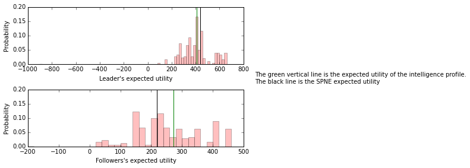

```python
numiters = 200
exparam = .0025
mcmcres = []
mcmcutils =[]
ixlist = np.arange(0, len(perfect_stratprofiles))
s0 = perfect_stratprofiles[np.random.choice(ixlist)]
for prop in xrange(numiters):
    s1 = perfect_stratprofiles[np.random.choice(ixlist)]
    arcriteria = np.exp(exparam * (sum(EU_perfect_info(s1[0], s1[1])) - sum(EU_perfect_info(s0[0], s0[1]))
                                   + EU_perfect_info(s1[0], s0[1])[0] + EU_perfect_info(s0[0], s1[1])[1]
                                   - EU_perfect_info(s0[0], s1[1])[0] - EU_perfect_info(s1[0], s0[1])[1]))

    #num =  np.exp(exparam * EU_perfect_info(s1[0], sc[1])[0]) * np.exp(exparam*EU_perfect_info(sc[0], s1[1])[1])
    #denom =  np.exp(exparam*EU_perfect_info(s0[0], sc[1])[0]) * np.exp(exparam*EU_perfect_info(sc[0], s0[1])[1])
    unew = EU_perfect_info(s1[0], s1[1])
    #num  = np.prod(unew)
    uold = EU_perfect_info(s0[0], s0[1])
    #denom = np.prod(uold)
    #num*= np.exp(exparam * EU_perfect_info(s1[0],s0[1])[0]) * np.exp(exparam*EU_perfect_info(s0[0], s1[1])[1])
    #denom*= np.exp(exparam * EU_perfect_info(s0[0], s1[1])[0]) *  np.exp(exparam * EU_perfect_info(s1[0],s0[1])[1])
    #arcriteria = (num/denom)
    #arcriteria = 1
    if np.random.random() < arcriteria:
        mcmcres.append(s1)
        s0 = s1
        mcmcutils.append(unew)
    else:
        mcmcres.append(s0)
        mcmcutils.append(uold)

mcmcutils = np.asarray(mcmcutils)
eu_subgame_perfect = [(625+250)/2. , (312. + 125.)/2.]
fig, (ax1, ax2) = plt.subplots(2)
weights1 = np.ones_like(mcmcutils[20:, 0])/len(mcmcutils[20:, 0])
ax1.hist(mcmcutils[20:, 0], weights=weights1, bins=np.arange(-900,800,20), color='r', alpha=.25)
ax1.set_xlabel("Leader\'s expected utility")
ax1.set_ylabel("Probability")
ax1.vlines(eu_subgame_perfect[0], 0, .2)
ax1.vlines(np.mean(mcmcutils[20:,0]), 0, .2, color='green')
weights2 = np.ones_like(mcmcutils[20:, 1])/len(mcmcutils[20:, 1])
ax2.hist(mcmcutils[20:, 1], weights=weights2, bins=np.arange(-200,500,20), color='r', alpha=.25)
ax2.set_xlabel("Followers\'s expected utility")
ax2.set_ylabel("Probability")
ax2.vlines(eu_subgame_perfect[1], 0, .2)
ax2.vlines(np.mean(mcmcutils[20:,1]), 0, .2, color='green')
plt.tight_layout()
fig.text(1, .5, 'The green vertical line is the expected utility of the intelligence profile. \n' + \
                        'The black line is the SPNE expected utility')
```

Compare that to the exhaustive search non-trembling, standard PGT distribution distribution with exhaustive search

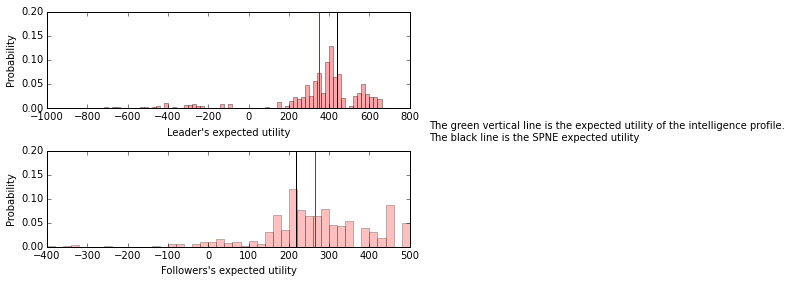

```python
res_notremble = TremblingIntelResults(no_trembling_intels)
res_notremble.eu_hist(binwidth=20, power=1);
```

Pretty darn close. This is with a maximum of 800 profile evaluations (not keeping anything in memory).To push the limits, let's see what happens when we drop the number of profiles to 100.

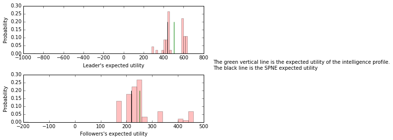

```python
numiters = 100
exparam = .025
mcmcres = []
mcmcutils =[]
ixlist = np.arange(0, len(perfect_stratprofiles))
s0 = perfect_stratprofiles[np.random.choice(ixlist)]
for prop in xrange(numiters):
    s1 = perfect_stratprofiles[np.random.choice(ixlist)]
    arcriteria = np.exp(exparam * (sum(EU_perfect_info(s1[0], s1[1])) - sum(EU_perfect_info(s0[0], s0[1]))
                                   + EU_perfect_info(s1[0], s0[1])[0] + EU_perfect_info(s0[0], s1[1])[1]
                                   - EU_perfect_info(s0[0], s1[1])[0] - EU_perfect_info(s1[0], s0[1])[1]))

    #num =  np.exp(exparam * EU_perfect_info(s1[0], sc[1])[0]) * np.exp(exparam*EU_perfect_info(sc[0], s1[1])[1])
    #denom =  np.exp(exparam*EU_perfect_info(s0[0], sc[1])[0]) * np.exp(exparam*EU_perfect_info(sc[0], s0[1])[1])
    unew = EU_perfect_info(s1[0], s1[1])
    #num  = np.prod(unew)
    uold = EU_perfect_info(s0[0], s0[1])
    # denom = np.prod(uold)
    # num*= np.exp(exparam * EU_perfect_info(s1[0],s0[1])[0]) * np.exp(exparam*EU_perfect_info(s0[0], s1[1])[1])
    # denom*= np.exp(exparam * EU_perfect_info(s0[0], s1[1])[0]) *  np.exp(exparam * EU_perfect_info(s1[0],s0[1])[1])
    # arcriteria = (num/denom)
    # arcriteria = 1
    # print s0, s1, arcriteria
    if np.random.random() < arcriteria:
        mcmcres.append(s1)
        s0 = s1
        mcmcutils.append(unew)
    else:
        mcmcres.append(s0)
        mcmcutils.append(uold)

mcmcutils = np.asarray(mcmcutils)
eu_subgame_perfect = [(625+250)/2. , (312. + 125.)/2.]
fig, (ax1, ax2) = plt.subplots(2)
weights1 = np.ones_like(mcmcutils[10:, 0])/len(mcmcutils[10:, 0])
ax1.hist(mcmcutils[10:, 0], weights=weights1, bins=np.arange(-900,800,20), color='r', alpha=.25)
ax1.set_xlabel("Leader\'s expected utility")
ax1.set_ylabel("Probability")
ax1.vlines(eu_subgame_perfect[0], 0, .2)
ax1.vlines(np.mean(mcmcutils[10:,0]), 0, .2, color='green')
weights2 = np.ones_like(mcmcutils[10:, 1])/len(mcmcutils[10:, 1])
ax2.hist(mcmcutils[10:, 1], weights=weights2, bins=np.arange(-200,500,20), color='r', alpha=.25)
ax2.set_xlabel("Followers\'s expected utility")
ax2.set_ylabel("Probability")
ax2.vlines(eu_subgame_perfect[1], 0, .2)
ax2.vlines(np.mean(mcmcutils[10:,1]), 0, .2, color='green')
plt.tight_layout()
fig.text(1, .5, 'The green vertical line is the expected utility of the intelligence profile. \n' + \
                        'The black line is the SPNE expected utility')
```

### The issue

The odds ratio do not yield a probability distribution. For example, for joint strategy profiles $A$, $B$, and $C$, we can have $P(A)>P(B)$, $P(B)>P(C)$ and $P(C)>P(A)$, i.e. not transitive. So what do we do?

One answer is nothing. Why would we do nothing? Well for one, the algorithm works (at least for now).

So what do we have? Basically we have a new way to define the likelihood. It is as follows:

1. Construct a **Markov Chain** where the transition probabilities are given by the odds defined above.
2. Sample the Markov Chain for $T$ timesteps.
3. The PGT posterior weight we assign to a strategy profile $(s_1, s_2)$ is the stationary probability of being in state $(s_1, s_2)$ of the Markov Chain.

### Implications

Based on (3) above we see that:

1. All else equal, increasing the utility of player $i$ in strategy profile $(s_i, s_{-1})$ increases the probability weight on $(s_i, s_{-1})$.
2. Given strategy profile $(s_i, s_{-i})$, the probability assigned to $(s_i, s_{-i})$ goes down if the expected utility to $i$ under strategy profile $(s_i, s_{-i}')$ goes down. This can be thought of as down weighting non-credible threats where the "down-weighting" depends on how much of a threat it is.